# Figure Generation v5

D. Ford Hannum Jr.

7/28/2020

The fifth version of the figures.

# Figure 3

## a) UMAP Projection of Data

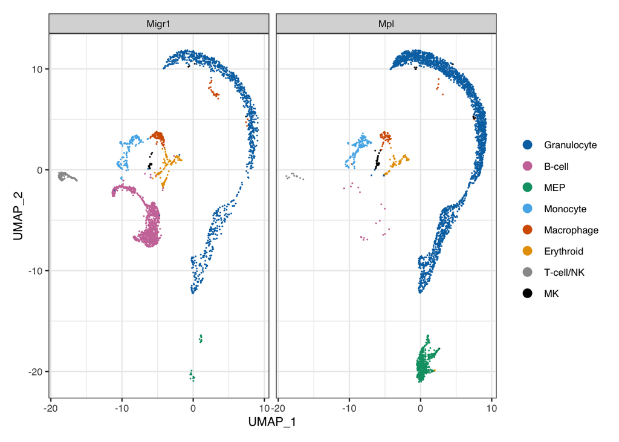

## b) Bar Quantification of Cell Counts

A bar graph for each condition (Migr1/Mpl) and the distribution of cells within each cluster

```
##    condition   cell_type count condition_count  perc comb_perc   Cell Type
## 1    Control Granulocyte   854            2014 42.40    133.04 Granulocyte
## 2        Mpl Granulocyte  2110            2328 90.64    133.04 Granulocyte
## 3    Control      B-cell   749            2014 37.19     37.66      B-cell
## 4        Mpl      B-cell    11            2328  0.47     37.66      B-cell
## 7    Control    Monocyte   152            2014  7.55     10.86    Monocyte
## 8        Mpl    Monocyte    77            2328  3.31     10.86    Monocyte
## 13   Control   T-cell/NK   126            2014  6.26      6.69   T-cell/NK
## 14       Mpl   T-cell/NK    10            2328  0.43      6.69   T-cell/NK
## 11   Control   Erythroid    60            2014  2.98      5.13   Erythroid
## 12       Mpl   Erythroid    50            2328  2.15      5.13   Erythroid
## 9    Control  Macrophage    54            2014  2.68      3.28  Macrophage
## 10       Mpl  Macrophage    14            2328  0.60      3.28  Macrophage
## 5    Control         MEP    10            2014  0.50      2.22         MEP
## 6        Mpl         MEP    40            2328  1.72      2.22         MEP
## 15   Control          MK     9            2014  0.45      1.14          MK
## 16       Mpl          MK    16            2328  0.69      1.14          MK
```

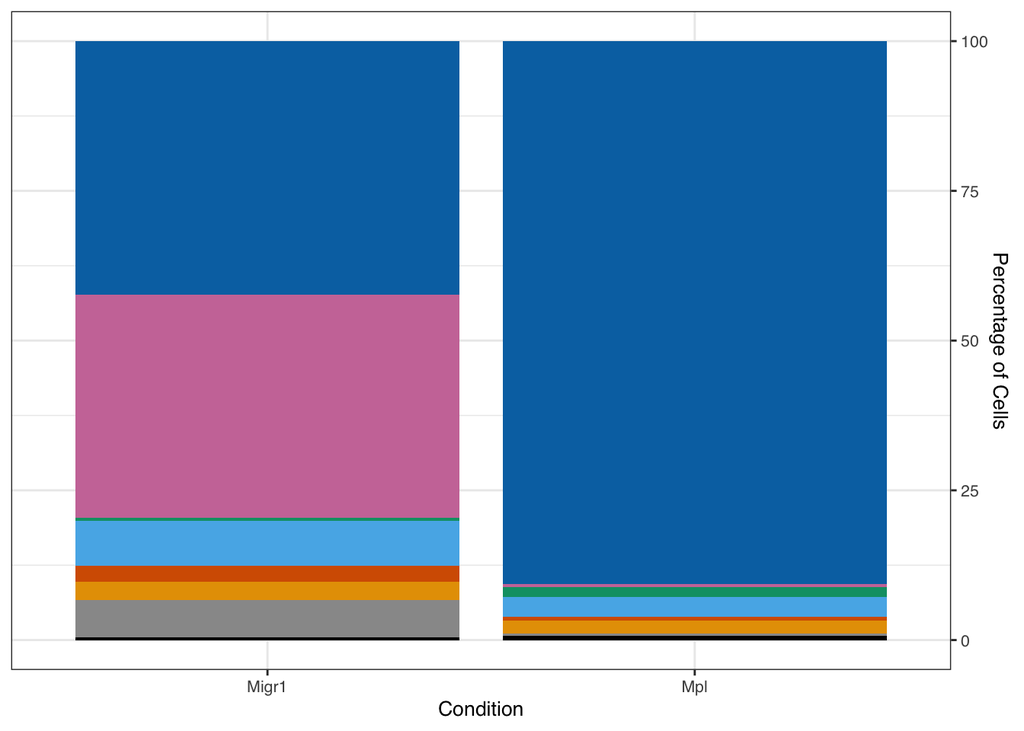

**Figure Legend** b) Percentage o cells distributed to each cluster for the two conditions (Migr1, Mpl). There is a clear increase in the percentage of cells coming from the granulocyte cluster (blue) in Mpl (90%) compared to Migr1 (42%). There is also a decrease in the number of B-cells (pink) in Migr1 (37%) to Mpl (0.5%), and T-cells/NKs in Migr1 (6%) to Mpl (0.4%).

*Note* Not sure if I should add more examples. Also can include the table in supplementary figures.

## c) Marker Plots

Originally the though was to due violing plots for marker genes, but here I am looking at doing a dot plot.

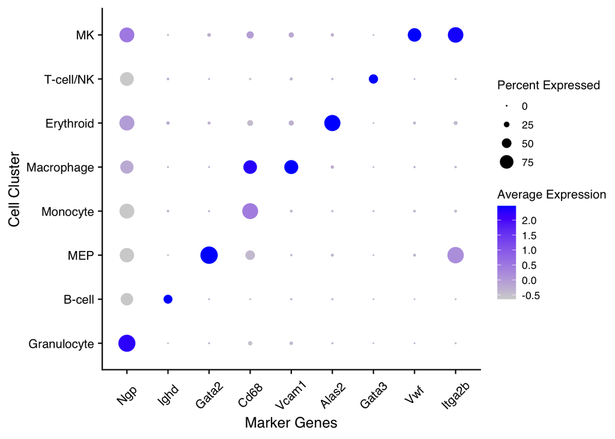

**Figure Legend** c) A dot plot of marker gene expression in the clusters. Circle size represents the percentage of cells in each cluster that express the marker gene. Color represents the average expression of the marker gene in the cluster. Large dark circles indicate marker genes are expressed highly in the majority of cells in a cluster.

## Literature for Markers:

**Ngp**: from uniprot “Expressed in myeloid bone marrow cells. Expressed in neutrophilic precursors (at protein level) (PubMed:8749713). Expressed in myeloid bone marrow cells (PubMed:21518852)”

**Ighd**: immunoglobulin heavy constant delta. Seems to clearly be expressed by B-cells, but still working on a good reference.

**Gata2**: From Krause paper: a transcription factor required for both lineages but bind in different combinations [ref](https://ashpublications.org/blood/article/113/10/2191/24361/SCL-and-associated-proteins-distinguish-active)

**Cd68**: a human macrophage marker [ref](https://pubmed.ncbi.nlm.nih.gov/7680921/). A more general [ref](https://www.nature.com/articles/labinvest2016116/)

**Vcam1**: found papers using Vcam1+ monocytes, but haven’t found a great reference.

**Alas2**: an erythroid-specfiic 5-aminolevulinate synthase gene [ref](https://pubmed.ncbi.nlm.nih.gov/12663458/)

**Gata3**: plays a role in the regulation of T-cells [ref](https://www.ncbi.nlm.nih.gov/pmc/articles/PMC2998182/)

**Vwf** and **Itga2b**: I figure the reference would best be left to y’all.